# SynergyLMM - Guided Tutorial

## Introduction

This vignette describes the different functions provided in ‘SynergyLMM’ package to analyze drug combination effects in preclinical *in vivo* studies.

We will follow the workflow for the analysis of a longitudinal tumor growth experiments for the evaluation of the effect of a drug combination and determine whether synergy (or antagonism) is present.

The following figure represent schematically ‘SynergyLMM’ workflow:

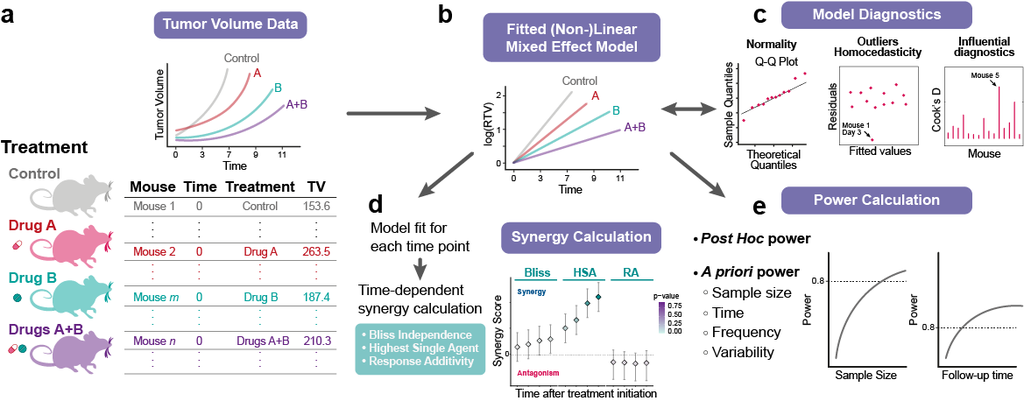

**Overview of the ‘SynergyLMM’ workflow. a,** The first step is uploading the longitudinal tumor burden-related measurements for the different treatment groups. The input consists of a tabular data in long format with at least 4 columns containing information about the samples IDs, the time points for each measurement, the treatment group, and the tumor measurement. **b,** The input data will then be processed to estimate the linear mixed effect model that fits the tumor growth dynamics for each subject, and estimate the growth rates for each treatment group. **c,** ‘SynergyLMM’ offer various functions to evaluate the model diagnostics and model performance, as well as for the identification of potential outliers and influential individuals for the model fit and the treatment groups. **d,** Once a proper model with satisfactory diagnostics has been obtained, the statistical assessment of combination effects is performed, with a time dependent estimation of the synergy score and combination index, along with their confidence intervals and statistical significance. The method allows for testing synergy using three reference models: Bliss independence, highest single agent (HSA), and response additivity (RA). **e,** ‘SynergyLMM’ implements versatile functions to calculate the *post hoc* power of the experiment and the *a priori* power by modifying the values of key experimental variables, such as sample size, follow-up time, or frequency of the measurements.

## 0. Recommended Workflow

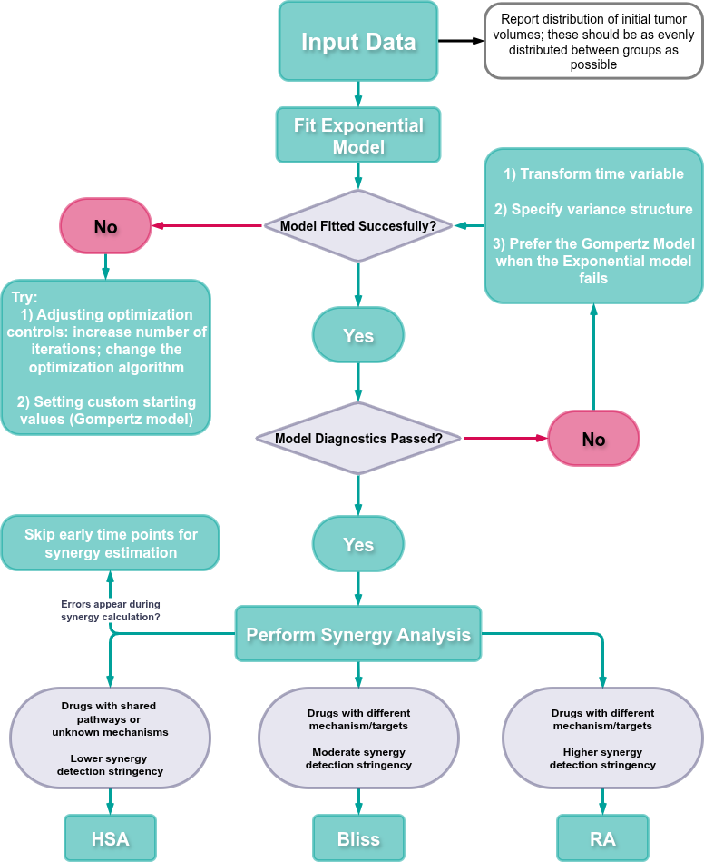

**Recommended workflow for using SynergyLMM** to assess drug combination effects. HSA: highest single agent. RA: response additivity.

## 1. Data Upload and Model Fit

We will start by loading ‘SynergyLMM’ package:

```r
> library(SynergyLMM)
```

For this tutorial, we will use the example dataset that is included in the package:

```r
> data("grwth_data")
```

Let’s have a look to these data:

```r
> head(grwth_data)
```

```
#>   subject Time Treatment TumorVolume
#> 1       1    0   Control    177.5810
#> 2       1    3   Control    242.5453
#> 3       1    6   Control    423.9744
#> 4       1    9   Control    416.6808
#> 5       1   12   Control    535.8457
#> 6       1   15   Control    891.7920
```

This is a typical example of *long data format*, in which each row is one time point per subject. So each subject (mouse) will have data in multiple rows. Any variables that don’t change across time will have the same value in all the rows.

In this case, column `subject` indicates the sample ID for each mouse, column `Time` indicates the time points (days) for each measurement, column `Treatment` indicates the treatment group to which the mouse belongs, and `TumorVolume` indicates the tumor volume measured for that mouse at that specific time point.

It is important to note that the `TumorVolume` column contains the *raw* measurements of tumor volume, in the sense that they have not been normalized or transformed.

In this experiment there are 4 groups: the control group, each mono-therapy group, and the drug combination group. Each group is identified with the following names:

```r
> unique(grwth_data$Treatment)
```

```
#> [1] Control     DrugA       DrugB       Combination
#> Levels: Control DrugA DrugB Combination
```

The output shows the different names for each treatment. We can also see that this column is stored as a `factor`. This is convenient, but not necessary. Those are the four columns that the dataset must have to be able to perform the analysis. The input data could have additional columns, but they will be ignored.

### 1.1 Exponential Model Fitting

Let’s start with the analysis by fitting the model. This is done with `lmmModel()` function:

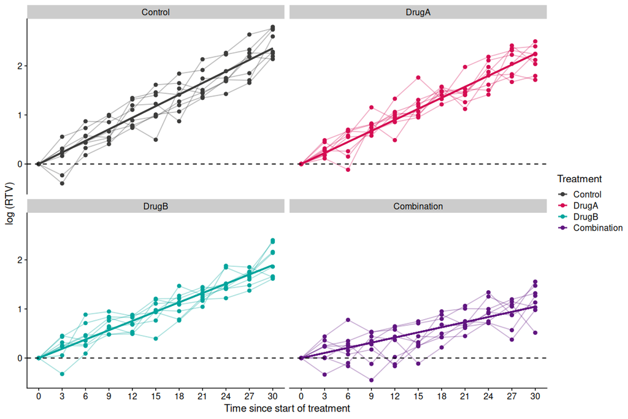

```r
> lmm_ex <- lmmModel(
   data = grwth_data,
   grwth_model = "exp",
   sample_id = "subject",
   time = "Time",
   treatment = "Treatment",
   tumor_vol = "TumorVolume",
   trt_control = "Control",
   drug_a = "DrugA",
   drug_b = "DrugB",
   combination = "Combination"
 )
```

This is the most basic use of the function to fit the model. The user needs to specify the names of the columns containing the information for the subject IDs, time points, treatment groups, tumor measurements, and the names used to refer the different groups.

Note the argument `grwth_model = "exp"`. This means the model will be fitted using a linear mixed-effect model assuming an **exponential tumor growth**. Users can also use a **Gompertz growth model**, which is presented in section 1.2 Gompertz Model Fitting.

`lmmModel()` fits the model, which we have stored in the `lmm_ex` object, and which we will use in the next steps. A plot with the tumor growth data for the different groups is also produced. The bold lines in the plots represent the fitted lines for the fixed effects of each treatment estimated by the linear mixed-effect model. The x-axis identifies the time since the start of treatment, being 0 the time of treatment initiation. The y-axis represent the $\log$ of the relative tumor volume ($RTV$).

There are several additional arguments in `lmmModel()` function:

- `time_start`: can be used to change the day that should be considered as the initial time point, which, by default, is the minimum value in `time` column.
- `time_end`: can be used to indicate the last time point to be included in the analysis, which, by default, is the maximum value in `time` column.
- `min_observations`: can be used to define the minimum number of observations (data points) that a subject should have to be considered in the analysis.
- `tum_vol_0`: this arguments allows to control the behavior regarding measurements in which the tumor measurement is 0, and therefore the logarithmic transformation is not possible. The user can choose to to ignore these measurements, or transform them, by adding 1 unit to all measurements before the $\log$ transformation.

### 1.2 Gompertz Model Fitting

While the exponential model is generally a good starting point for most *in vivo* studies, and it tends to converge more easily, it may be insufficient when tumor growth dynamics deviate significantly from exponential behavior. In such cases, a Gompertz growth model typically offers better flexibility and more accurate estimates of tumor growth and treatment effects. Users can fit a non-linear mixed effect model using a Gompertz growth model by specifying `grwth_model = "gompertz"`:

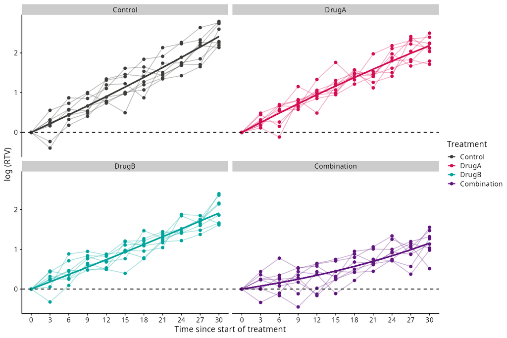

```r
> lmm_gomp <- lmmModel(
   data = grwth_data,
   grwth_model = "gompertz",
   start_values = "selfStart",
   sample_id = "subject",
   time = "Time",
   treatment = "Treatment",
   tumor_vol = "TumorVolume",
   trt_control = "Control",
   drug_a = "DrugA",
   drug_b = "DrugB",
   combination = "Combination"
   )
```

When using the Gompertz growth model, setting `start_values = "selfStart"` derives the initial values from a call to `stats::nls`, which can facilitate successful model fitting.

### 1.3 Model Estimates

We can obtain the values of the **model estimates** using the function `lmmModel_estimates()`. This function retrieves the information about the estimated coefficients (tumor growth rates) for the different experimental groups, as well as the standard deviation of the random effects (between-subject variance) and residuals (within-subject variance).

```r
> lmmModel_estimates(lmm_ex)
```

```
#>      Control se_Control      DrugA   se_DrugA      DrugB   se_DrugB Combination
#> 1 0.07855242 0.00322683 0.07491984 0.00322683 0.06306986 0.00322683  0.03487933
#>   se_Combination   sd_ranef  sd_resid
#> 1     0.00322683 0.03946667 0.2124122
```

## 2. Model Diagnostics

Before performing the synergy analysis, it is important to evaluate the **model diagnostics** to check the main assumptions of the model: the normality of the random effects and the residuals.

It is important to verify that the model is appropriate for the data. Reliable results from statistical tests require that model assumptions — such as normality and homoscedasticity of random effects and residuals — are met. Therefore, users are recommended to thoroughly evaluate the estimated model, as certain experimental data sets may result in highly imprecise estimates.

### 2.1 Random Effects Diagnostics

To perform the diagnostics of the random effects we can use `ranefDiagnostics()`. This function provides plots and results from statistical tests to address the normality of the random effects. The random effects in our model correspond to a random slope for each subject, which takes into account the longitudinal nature of the data. Additional plots and tests related to the normality and homoscedasticity of the residuals for the subjects are also provided, which can help to identify subjects with extreme behaviors, and which could potentially being responsible for departure of the normality of random effects.

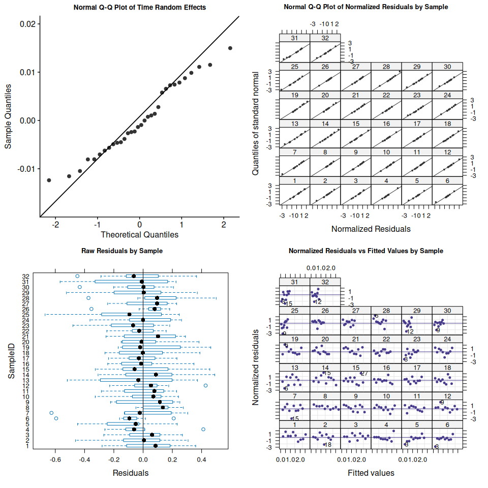

```
#>
#> Normality Test of Random Effects
#> $Time
#>
#> Title:
#>  Shapiro - Wilk Normality Test
#>
#> Test Results:
#>   STATISTIC:
#>     W: 0.9672
#>   P VALUE:
#>     0.4269
#>
#> Description:
#>  Normality Test of Time random effects
#>
#>
#> Normalized Residuals Levene Homoscedasticity Test by Sample
#> Levene's Test for Homogeneity of Variance (center = median)
#>        Df F value Pr(>F)
#> group  31   0.874 0.6633
#>       288
#>
#> Normalized Residuals Fligner-Killeen Homoscedasticity Test by Sample
#>
#>  Fligner-Killeen test of homogeneity of variances
#>
#> data:  normalized_resid by SampleID
#> Fligner-Killeen:med chi-squared = 28.521, df = 31, p-value = 0.5942
```

```r
> ranefDiagnostics(lmm_ex)
```

The most important plot is the Q-Q plot at the top left, which shows the normal Q-Q plot of the random effects. The console output shows the results of a Shapiro - Wilk normality tests for the random effects. Other normalilty test are available with `norm_test` argument.

The normality of the random effects cannot be rejected if the p-value of the normality test is not significant, and/or the Q-Q plot shows that the data points approximately lie in the diagonal line. If some points lie significantly outside the line, they could be potential outliers that could be identified based on the residuals or in the **Influential Diagnostics**.

The console output also shows the results of Levene and Fligner-Killeen homoscedasticity test of the normalized residuals by sample. The homoscedasticity of the residuals among subjects cannot be rejected if the p-value of these tests is not significant.

In this example, it can be observed how the normality of the random effects cannot be rejected, although there are some outlier observations, that may deserve further examination.

### 2.2 Residual Diagnostics

One of the assumption of the model fit by `lmmModel()` is that the residuals are normally distributed. For the evaluation of this assumption, `residDiagnostics()` provides Q-Q plots of the normalized residuals together with statistical assessment of their normality using the normality test specified in `norm_test`. The Shapiro-Wilk normality test is used by default. Additionally, Q-Q plots of the normalized residuals by time point and treatment group are provided to be able to detect time points or treatment groups which could be notably different from the others and be affecting the adequacy of the model.

Scatter plots of the normalized residuals versus fitted values and normalized residuals per time and per treatment are also provided to give information about variability of the residuals and possible outlier observations. These plots are accompanied by Levene and Fligner-Killend homogeneity of variance test results.

Finally, potential outlier observations are also returned.

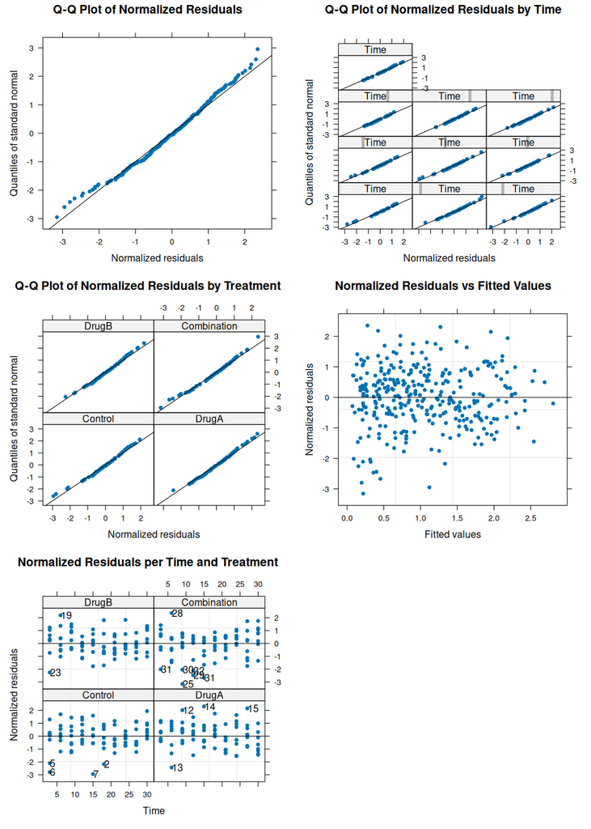

```
#>
#> Normalized Residuals Normality Test
#>
#> Title:
#>  Shapiro - Wilk Normality Test
#>
#> Test Results:
#>   STATISTIC:
#>     W: 0.9895
#>   P VALUE:
#>     0.02154
#>
#>
#> Normalized Residuals Levene Homoscedasticity Test by Time
#> Levene's Test for Homogeneity of Variance (center = median)
#>        Df F value Pr(>F)
#> group   9  0.4714 0.8934
#>       310
#>
#> Normalized Residuals Fligner-Killeen Homoscedasticity Test by Time
#>
#>  Fligner-Killeen test of homogeneity of variances
#>
#> data:  normalized_resid by as.factor(Time)
#> Fligner-Killeen:med chi-squared = 3.8143, df = 9, p-value = 0.9232
#>
#>
#> Normalized Residuals Levene Homoscedasticity Test by Treatment
#> Levene's Test for Homogeneity of Variance (center = median)
#>        Df F value Pr(>F)
#> group   3  0.5772 0.6304
#>       316
#>
#> Normalized Residuals Fligner-Killeen Homoscedasticity Test by Treatment
#>
#>  Fligner-Killeen test of homogeneity of variances
#>
#> data:  normalized_resid by Treatment
#> Fligner-Killeen:med chi-squared = 1.5405, df = 3, p-value = 0.673
#>
```

[output cut: 23 more lines]

```
#> 51         -2.796859
#> 65         -2.948355
#> 113         2.013734
#> 122        -2.439570
#> 135         2.306236
#> 149         2.147614
#> 182         2.178362
#> 221        -2.256830
#> 243        -3.153712
#> 272         2.352650
#> 284        -2.467379
#> 293        -2.037821
#> 301        -2.012043
#> 305        -2.670916
#> 314        -2.113725
```

```r
> residDiagnostics(lmm_ex)
```

As we can see, there is some departure from the normality of the residuals, as indicated by the normality tests and the top-left Q-Q plot. Additionally, there are several potential outlier observations according to their normalized residuals.

### 2.3 Solutions for Violations of Model Diagnostics

When diagnostic plots and tests show evident violations of the model assumptions, there are several solutions that may help improving the model:

1. Transform the time variable: Both exponential and Gompertz models are based on ordinary differential equations (ODEs), which can be formulated using arbitrary time scales. Applying transformations, such as the square root or logarithm (with +1 offset), can often improve model fit, enhance linearity, stabilize variance, and ensure better numerical performance. Importantly, when comparing the exact values of a drug combination synergy index, the models should use the same timescale.
2. Specify residual variance structure: SynergyLMM uses the `nlme` R package, which supports flexible variance and correlation structures. These allow for heterogeneous variances or within-group correlations, such as those based on subject, time point, treatment, or combinations of these. Applying these structures can substantially improve model diagnostics and the robustness of the estimates. This can be done with the `weights` argument in the `lmmModel()` function.
3. Carefully address potential outliers. Individuals or measurements highlighted as potential outliers may warrant further investigation to reveal the reasons behind unusual growth behaviors, and potentially exclude these before reanalysis, after careful reporting and justification.
4. Prefer the Gompertz model when the exponential model fails: While the exponential model is generally a good starting point for most *in vivo* studies, and it tends to converge more easily, it may be insufficient when tumor growth dynamics deviate significantly from exponential behavior. In such cases, the Gompertz model typically offers better flexibility and more accurate estimates of tumor growth and treatment effects.

We will try to improved the model by defining unequal variances for the errors. We can do this providing an additional argument, `weights`, when fitting the model, which will be passed to `nlme::lme()` function. For example, we can define the model adding a variance function to represent a different variance per subject using `nlme::varIdent()` function:

```r
> lmm_ex_var <- lmmModel(
   data = grwth_data,
   sample_id = "subject",
   time = "Time",
   treatment = "Treatment",
   tumor_vol = "TumorVolume",
   trt_control = "Control",
   drug_a = "DrugA",
   drug_b = "DrugB",
   combination = "Combination",
   weights = nlme::varIdent(form = ~ 1 | SampleID),
   show_plot = FALSE
 )
```

If we obtain the model estimates from this new model:

```r
> lmmModel_estimates(lmm_ex_var)
```

```
#>      Control se_Control      DrugA    se_DrugA      DrugB   se_DrugB
#> 1 0.07888867 0.00318583 0.07496401 0.003194576 0.06308966 0.00315647
#>   Combination se_Combination  sd_ranef  sd_resid
#> 1  0.03535055    0.003249592 0.0386823 0.2148223
```

We can observe that the values are slightly different from the previous `lmm_ex` model.

You can also try defining:

- A different variance per time using `nlme::varIdent(form = ~1|Time)`.
- A different variance per treatment group, using `nlme::varIdent(form = ~1|Treatment)`.
- Combinations of them using `nlme::varComb()` function.

We can now evaluate the diagnostics of the new model. We will use the option `verbose = FALSE` to avoid printing all the results in the console:

**Random Effects**

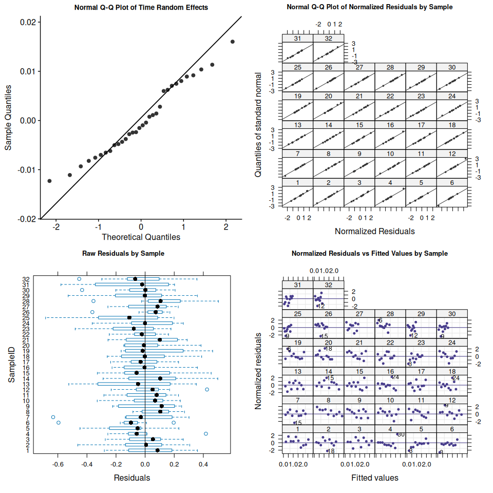

```r
> ranefD <- ranefDiagnostics(lmm_ex_var, verbose = FALSE)
```

```r
>
> # We can access to individual results of the diagnostics:
> ranefD$Normality
```

```
#> $Time
#>
#> Title:
#>  Shapiro - Wilk Normality Test
#>
#> Test Results:
#>   STATISTIC:
#>     W: 0.9671
#>   P VALUE:
#>     0.423
#>
#> Description:
#>  Normality Test of Time random effects
```

**Residuals**

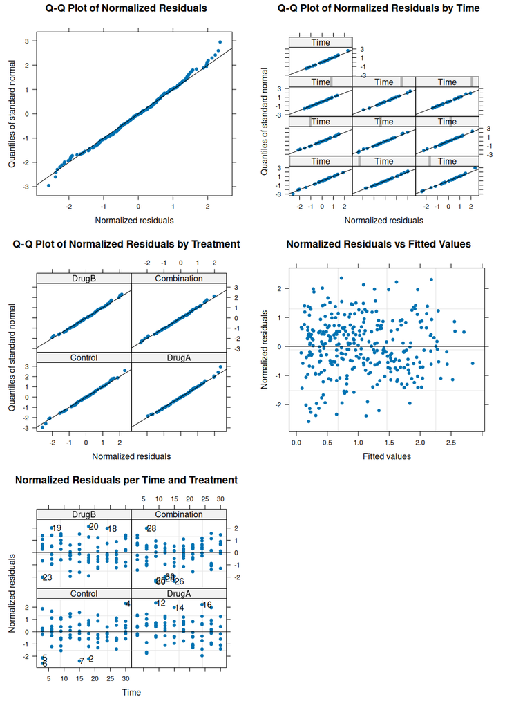

```r
> residD <- residDiagnostics(lmm_ex_var, verbose = FALSE)
```

```r
> residD$Normality
```

```
#>
#> Title:
#>  Shapiro - Wilk Normality Test
#>
#> Test Results:
#>   STATISTIC:
#>     W: 0.9945
#>   P VALUE:
#>     0.31
```

It can be observed there is no evidence of violation of the assumptions in the new model.

### 2.4 Model Performance

Another useful function to evaluate the model is `ObsvsPred()`. `ObsvsPred` allows the user to have a straight forward idea about how the model is fitting the data, providing plots of the predicted regression lines versus the actual data points.

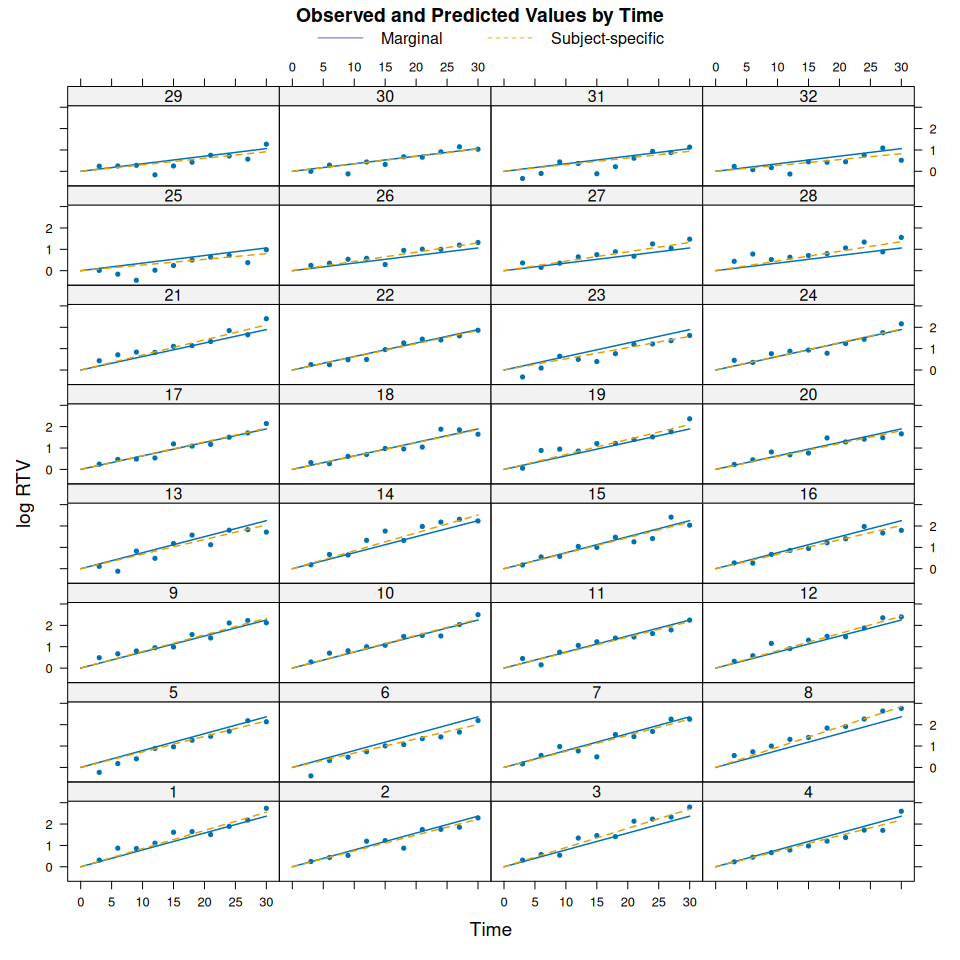

```
#> # Indices of model performance
#>
#> AIC  | AICc |   BIC | R2 (cond.) | R2 (marg.) |  RMSE | Sigma
#> -------------------------------------------------------------
#> 58.1 | 68.1 | 197.5 |      0.896 |      0.896 | 0.204 | 0.215
```

```r
> ObsvsPred(lmm_ex_var, nrow = 8, ncol = 4)
```

This function provides visual and quantitative information about the performance of the model:

- A layout of the observed and predicted values of $\log$(relative tumor volume) vs Time for each SampleID (i.e. subject). The actual measurements are shown as blue dots, the dashed orange line indicates the regression line for each subject, while the continuous blue line indicates the marginal, treatment-specific, regression line for each treatment group.
- Performance metrics of the model calculated using `performance::model_performance()`. The maximum likelihood-based Akaike’s Information Criterion (AIC), small sample AIC (AICc), and Bayesian Information Criterion, and the Nakagawa’s r-squared root mean squared error (RMSE) of the residuals, and the standard deviation of the residuals (sigma) are provided.

Smaller values of AIC, AICc, BIC, RMSE, and sigma of the residuals indicate a better-fitting model. $R^2$ values range from 0 to 1. An $R^2$ value closer to 1 suggests that the model explains a larger proportion of the variance in the data, indicating a better fit.

As we can see in the plots and the metrics, the model fits quite well the data, obtaining a high $R^2$ value.

### 2.5 Influential Diagnostics

Influential diagnostics allow the user to identify highly influential subjects (animals) in the experiment. These options include detecting those subjects with greater influence on the estimation of control and treatment group fixed effects, and subjects with greater influence on the fitted values, as evaluated using Cook’s distances using `CookDistances()`. For the exponential model, users can also identify subjects with a substantial impact on the overall model, as assessed with log-likelihood displacements using `logLikSubjectDisplacements()` function. Log-likelihood displacements are only available for models fitted using the exponential growth model.

**Cook’s Distances based on the change of fixed effect values**

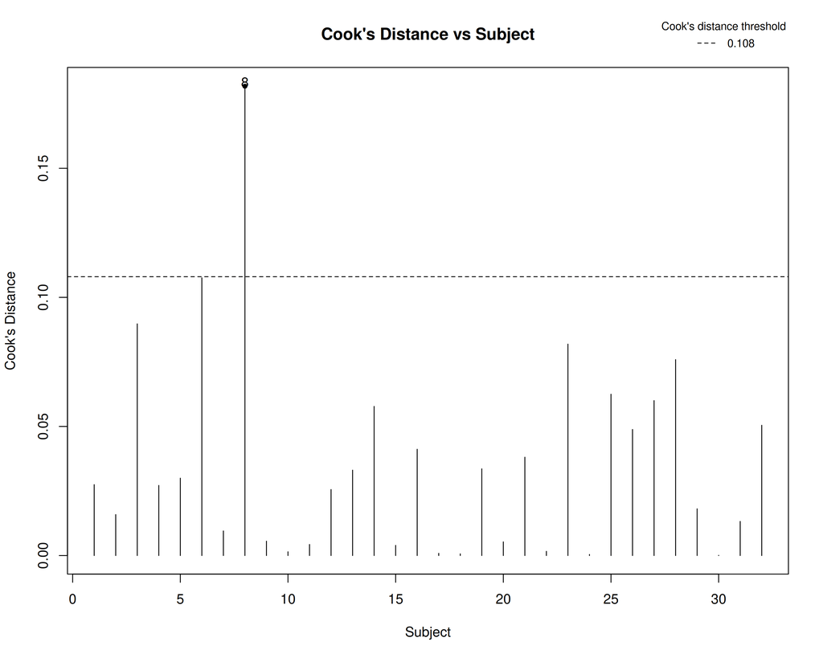

```r
> CookDistance(lmm_ex_var, type = "fixef")
```

**Cook’s Distances based on the change of fitted values**

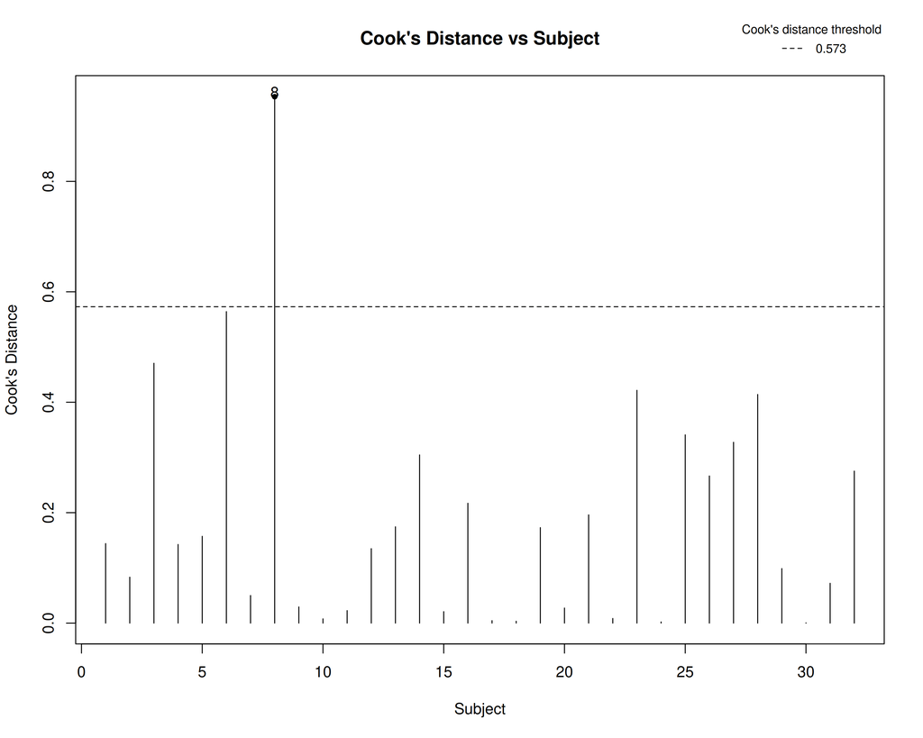

```r
> CookDistance(lmm_ex_var, type = "fitted")
```

It seems that subject 8 is a subject with a remarkable influence in both, the fixed effect values, and the fitted values.

We can check the log-likelihood displacements. Since we have defined a variance structure in the model, we need to specify an additional argument in the function, `var_name`:

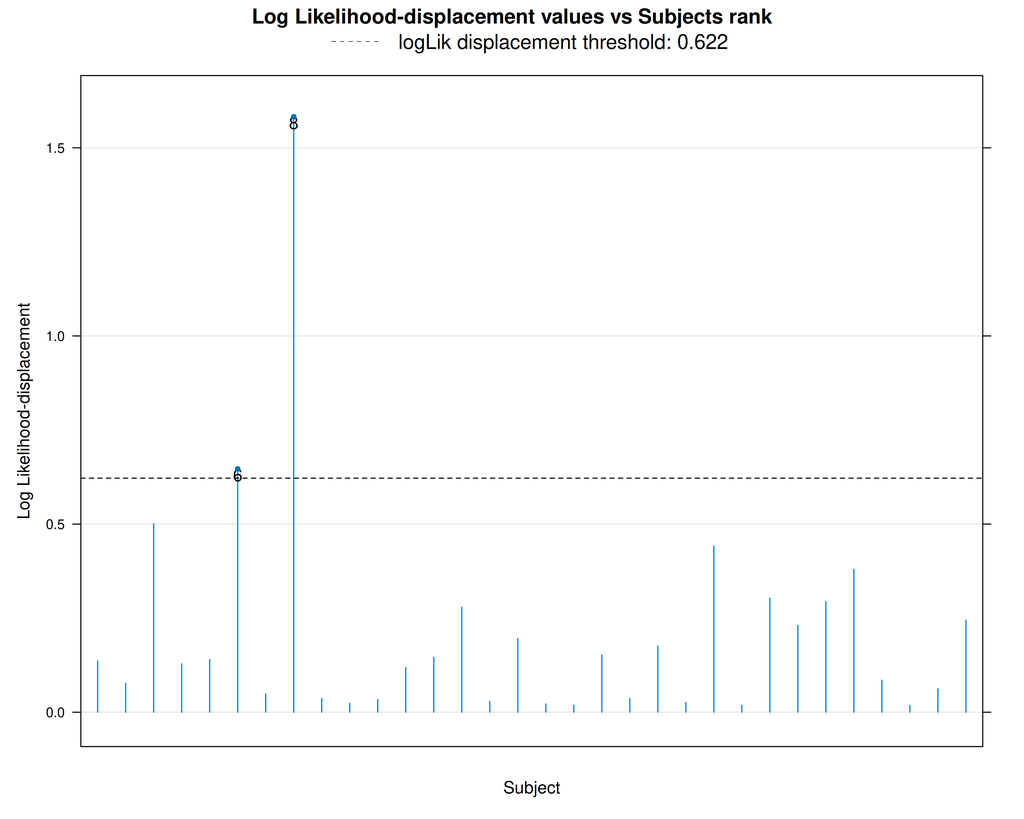

```r
> logLikSubjectDisplacements(lmm_ex_var, var_name = "SampleID")
```

Again, subject 8 seems to be having a higher influence in the model.

In a real data analysis, this results suggest that maybe the researcher should review the data regarding subject 8, to try to identify any reasons for the different behavior of this subject.

## 3. Synergy Analysis

After the careful examination of the model diagnostics and being sure that our model is correctly specified, we can proceed to the synergy analysis, using `lmmSynergy()` function.

`lmmSynergy()` allows for the calculation of synergy using 3 different references models: Bliss independence, highest single agent (HSA), and response additivity (RA). The calculation of synergy is based on hypothesis testing on the coefficient estimates from the model fitted by `lmmModel()`.

We will perform the analysis for the **Bliss independence model**

When a variance structure has been specified, it is recommended to set the argument `robust = TRUE`, to use cluster-robust variance estimation using `clubSandwich::vcovCR.lme()`.

```r
> bliss <- lmmSynergy(lmm_ex_var, method = "Bliss", robust = TRUE)
```

```
#> Error in big_mat[ind, ind] <- small_mat[[i]] + big_mat[ind, ind]: replacement has length zero
```

However, as it can be seen, sometimes this can result in some errors, due to the impossibility to fit the model at the earlier time points (due to convergence problems caused by insufficient data compared to the number of parameters to estimate). In these cases, an easy solution is to simply increase the value of the `min_time` argument, to increase the minimum time for which to start calculating the synergy:

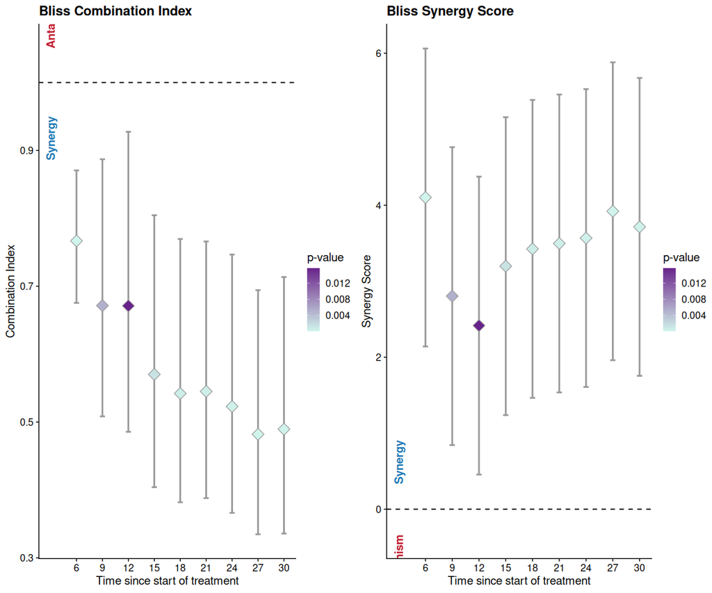

```r
> bliss <- lmmSynergy(lmm_ex_var, method = "Bliss", robust = TRUE, min_time = 6)
```

Now we can observe the results, which indicate that the drug combination effect is synergistic through all the time points.

The synergy analysis results can be obtained from the object as:

```r
> bliss$Synergy
```

```
#>    Model Metric  Estimate       lwr       upr         pval Time
#> 1  Bliss     CI 0.7668269 0.6754590 0.8705540 4.103824e-05    6
#> 2  Bliss     CI 0.6714793 0.5083305 0.8869906 5.041554e-03    9
#> 3  Bliss     CI 0.6711078 0.4856233 0.9274384 1.567663e-02   12
#> 4  Bliss     CI 0.5701287 0.4040469 0.8044779 1.382189e-03   15
#> 5  Bliss     CI 0.5420798 0.3818478 0.7695488 6.142903e-04   18
#> 6  Bliss     CI 0.5451376 0.3879895 0.7659356 4.707607e-04   21
#> 7  Bliss     CI 0.5229272 0.3662528 0.7466234 3.595666e-04   24
#> 8  Bliss     CI 0.4820073 0.3346676 0.6942145 8.827451e-05   27
#> 9  Bliss     CI 0.4894694 0.3357710 0.7135230 2.029750e-04   30
#> 10 Bliss     SS 4.1015553 2.1415913 6.0615193 4.103824e-05    6
#> 11 Bliss     SS 2.8043667 0.8444027 4.7643306 5.041554e-03    9
#> 12 Bliss     SS 2.4163583 0.4563943 4.3763223 1.567663e-02   12
#> 13 Bliss     SS 3.1983449 1.2383809 5.1583089 1.382189e-03   15
#> 14 Bliss     SS 3.4252251 1.4652611 5.3851891 6.142903e-04   18
#> 15 Bliss     SS 3.4968646 1.5369006 5.4568286 4.707607e-04   21
#> 16 Bliss     SS 3.5681092 1.6081452 5.5280732 3.595666e-04   24
#> 17 Bliss     SS 3.9207481 1.9607841 5.8807121 8.827451e-05   27
#> 18 Bliss     SS 3.7152848 1.7553208 5.6752488 2.029750e-04   30
```

This data frame contains the synergy results, indicating the model of synergy (“Bliss”, “HSA” or “RA”), the metric (combination index and synergy score), the value of the metric estimate (with upper and lower confidence interval bounds) and the p-value, for each time.

We can repeat the process for the **highest single agent (HSA)** model:

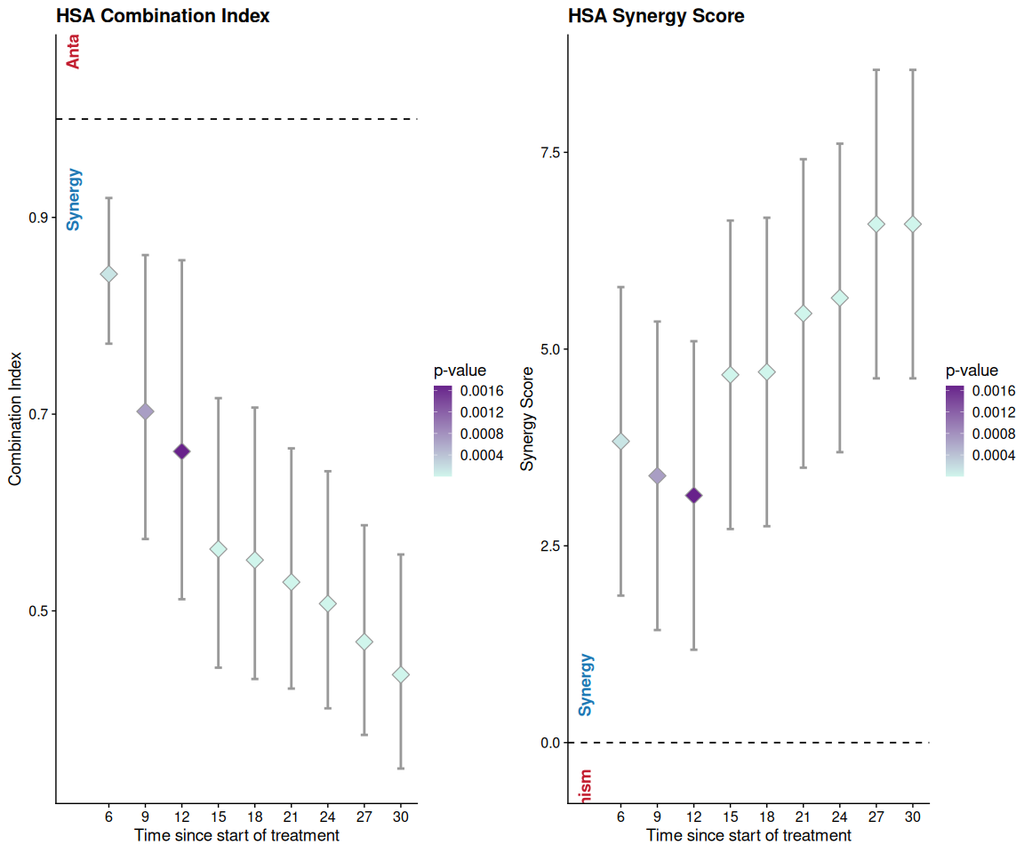

```r
> hsa <- lmmSynergy(lmm_ex_var, method = "HSA", robust = TRUE, min_time = 6)
```

As expected the results are similar, indicating synergy, but with smaller p-values compared to the Bliss model.

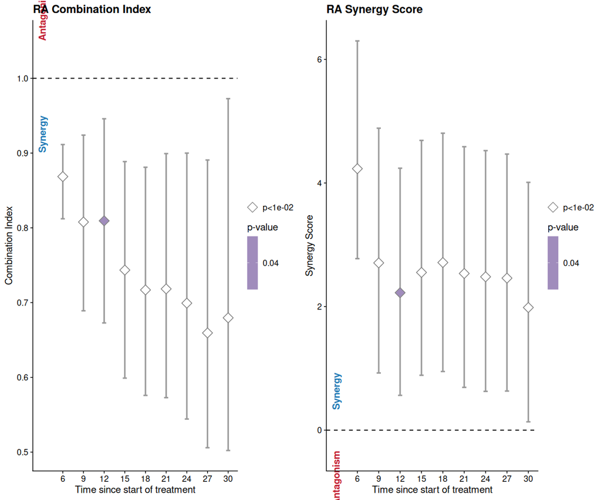

```r
> ra <- lmmSynergy(lmm_ex_var, method = "RA", robust = TRUE, min_time = 6, nsim = 100)
```

Since we performed 100 simulations, the minimum p-value is 0.01. If we would like to obtain more precise p-values, we should run the analysis increasing the number of simulations.

## 4. Power Analysis

‘SynergyLMM’ implements statistical power analysis to improve experimental designs.

*Post-hoc* and *a priori* power analysis are only available for models fitted using the **exponential growth** model, and for **Bliss independence** and **HSA** synergy reference models.

### 4.1 *Post Hoc* Power Analysis

The *post hoc* (retrospective) power analysis allows to evaluate the statistical power for the provided data set and fitted model. Traditionally, a threshold of 0.8 (80%) is used as an acceptable level of power ([Serdar CC et al., 2021](https://www.biochemia-medica.com/en/journal/31/1/10.11613/BM.2021.010502)).

‘SynergyLMM’ allows for the *post hoc* power analysis of the synergy hypothesis testing for Bliss and HSA reference models for a given tumor growth data with `PostHocPwr()` function.

Since the drug combination effect is time-dependent, the statistical power vary depending on the time point being analyzed. We can choose which time point to analyse using the `time` argument.

The post hoc power analysis is based on simulations. We can specify the number of simulations to run using the `nsim` argument. For this example, we will run only 50 simulations to reduce the computational time:

If we don’t specify any day, the last time point is used by default (in this case, day 30):

```r
> PostHocPwr(lmm_ex_var, nsim = 50, method = "Bliss")
```

```
#> [1] 0.98
```

We can see that the analysis provides a good statistical power.

### 4.2 *A Priori* Power Analysis

Prospective, *a priori*, statistical power analysis allows to assess how the statistical power of the analysis varies with variations of some parameters such as the sample size, or drug combination effect size, while keeping the other parameters constant. The *a priori* power analysis can help to implement improved experimental designs for *in vivo* experiments with minimal number of animals and measurements, yet still having enough statistical power to detect true synergistic effects.

#### Sample Size Power Analysis

`PwrSampleSize()` allows to calculate the *a priori* statistical power with different sample sizes. We can modify any of the parameters, such as the time points of the experiment, the growth rate of the different groups, or the variance in the model (given by the standard deviation of the random effects and residuals).

However, usually the researcher will be interested in analyzing the *a priori* power for an experiment, to check, for example, which sample size should be used in order to reach an appropriate statistical power. We can do this using the `lmmModel_estimates()` function, to retrieve the model estimates from the experiment, and then play with the different parameters:

First, lets extract the information from our experiment:

```r
> # Vector with the time points
> days <- unique(grwth_data$Time)
>
> # Model estimates
> estimates <- lmmModel_estimates(lmm_ex_var)
> estimates <- round(estimates, 3) # rounding for nicer presentation
```

Now, we can evaluate the *a priori* power for this experiment, varying the sample size per group. For example, let’s evaluate how the sample size varies from 1 to 10 subjects per group:

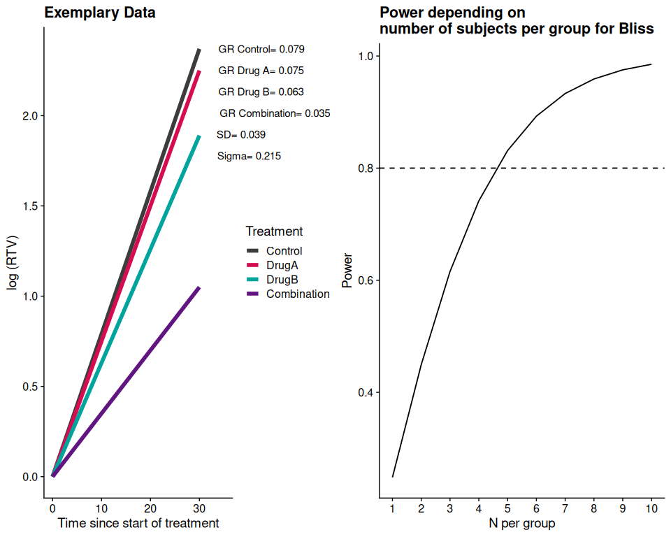

```
#>     N     Power
#> 1   1 0.2482717
#> 2   2 0.4493088
#> 3   3 0.6155939
#> 4   4 0.7415295
#> 5   5 0.8313583
#> 6   6 0.8926689
#> 7   7 0.9331076
#> 8   8 0.9590544
#> 9   9 0.9753267
#> 10 10 0.9853362
```

```r
> PwrSampleSize(npg = 1:10,
               time = days,
               grwrControl = estimates$Control,
               grwrA = estimates$DrugA,
               grwrB = estimates$DrugB,
               grwrComb = estimates$Combination,
               sd_ranef = estimates$sd_ranef,
               sgma = estimates$sd_resid,
               method = "Bliss",
               plot_exmpDt = TRUE)
```

The plot on the left represents the hypothetical data that we have provided, with the regression lines for each treatment group according to `grwrControl`, `grwrA`, `grwrB`, and `grwrComb` values. The values assigned to `sd_ranef` and `sgma` are also shown. The `plot_exmpDt` argument allows the user to control whether this plot is displayed.

The plot on the right shows the values of the power calculation depending on the values assigned to `npg`. We can observed that, for this experiment, a sample size of 5 would be enough to reach 0.8 statistical power.

#### Time Power Analysis

The number of measurement points per subject is another experimental factor that can influence the experimental design and statistical power. This depends on the duration of tumor growth follow-up and the frequency of the measurements during that period. `PwrTime()` function allows for the *a priori* power calculation of a a hypothetical two-drugs combination study of synergy depending on the time of follow-up or the frequency of measurements.

For example, the researcher may be interested in studying the statistical power of the experiment depending on the time of follow-up, to decide the appropriate end point. If we set the argument `type = "max"` in `PwrTime()` function, we can evaluate how the power varies at different end times. For this, we need to provide the function with a list of vectors with the times at which the tumor measurements are performed. As we are interested in addressing how the power varies for different study duration, the measurement should be taken at the same intervals.

Let’s see an example. Using the estimates from the model we have fitted previously, we can explore how the power varies if the study ends in a range from 9 to 30 days, with measurements performed every 3 days.

The first step is to define the list of vectors tumor measurements time points:

```r
> max_time <- list(seq(0,9,3), seq(0,12,3), seq(0,15,3),
                  seq(0,18,3), seq(0,21,3), seq(0,24,3),
                  seq(0,27,3), seq(0,30,3))
```

Another argument for the function is `npg`, which indicates the sample size per group. As we are interested in calculate the *a priori* power for different study duration in our experiment and model, we will use the mean sample size per group in the experiment:

```r
> # We can calculate the average sample size dividing the number of subjects
> # by the number of groups, in this case, 4 groups
> (npg <- round(length(unique(grwth_data$subject))/4,0))
```

```
#> [1] 8
```

Now, the *a priori* power for the Bliss independence model at different end points of the study is:

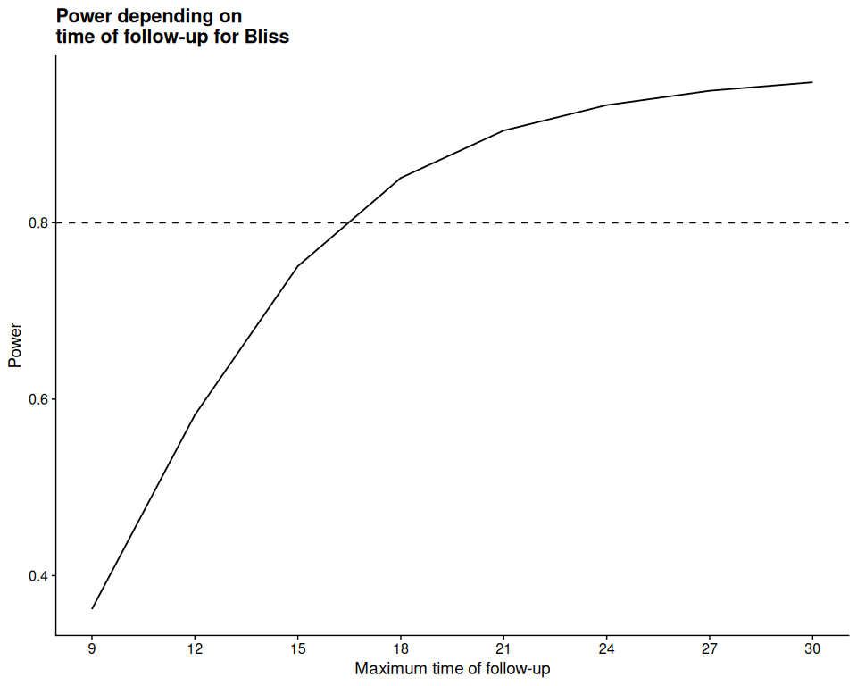

```
#>   Time     Power
#> 1    9 0.3620678
#> 2   12 0.5821139
#> 3   15 0.7506802
#> 4   18 0.8507028
#> 5   21 0.9044000
#> 6   24 0.9332249
#> 7   27 0.9494161
#> 8   30 0.9590544
```

```r
> PwrTime(npg = npg,
         time = max_time,
         type = "max",
         grwrControl = estimates$Control,
               grwrA = estimates$DrugA,
               grwrB = estimates$DrugB,
               grwrComb = estimates$Combination,
               sd_ranef = estimates$sd_ranef,
               sgma = estimates$sd_resid,
               method = "Bliss")
```

We can observe that a study with a follow-up time of 18 days would be enough to achieve a statistical power > 0.8, if all the other variables do not vary.

Now, we may also wonder how frequently the measurements should be taken. Is it necessary to take measurements every 3 days, or can we reduce the measurements to every 6 days?

We can do this by setting the `type = "freq"` argument in `PwrTime()` function. In this case, we need to provide a list of vectors with the tumor measurements with the same maximum time of follow-up, but changing the intervals at which the measurements have been taken. Let’s first define this list. We will evaluate how many measurements are needed in an experiment with a follow-up period of 18 days.

```r
> freq_time <- list(seq(0,18,1), seq(0,18,3), seq(0,18,6), seq(0,18,9),seq(0,18,18))
```

Now, let’s analyze the *a priori* power:

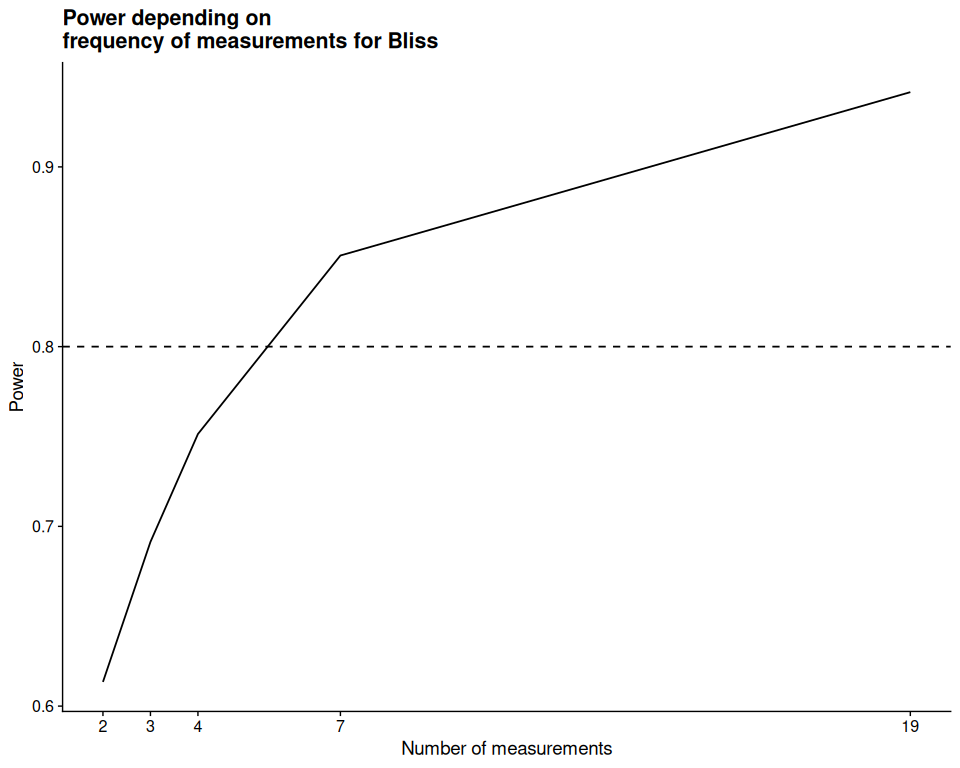

```
#>   Time     Power
#> 1   19 0.9416027
#> 2    7 0.8507028
#> 3    4 0.7513935
#> 4    3 0.6913582
#> 5    2 0.6134500
```

```r
> PwrTime(npg = npg,
         time = freq_time,
         type = "freq",
         grwrControl = estimates$Control,
         grwrA = estimates$DrugA,
         grwrB = estimates$DrugB,
         grwrComb = estimates$Combination,
         sd_ranef = estimates$sd_ranef,
         sgma = estimates$sd_resid,
         method = "Bliss")
```

The results show that with 4 measurements, which corresponds to take measurements every 6 days, the statistical power is close to 0.8.

#### Variability Power Analysis

A key determinant of statistical power is the effect size of the drug combination effect, given by the magnitude of the estimated coefficient for the growth rate after combination treatment, relative to that observed in the monotherapy and control groups. Treatments with larger effect sizes are easier to detect, even with smaller sample sizes, resulting in higher statistical power. Another critical factor is the variance components of the model, including residual variance (within-subject variance) and random effects variance (between-subject variance). High estimated coefficients for these variances reduce precision, thereby diminishing statistical power.

`APrioriPwr()` function allows for total customization of an hypothetical drug combination study and allows the user to define several experimental parameters, such as the sample size, time of measurements, or drug effect, for the power evaluation of synergy for Bliss and HSA reference models.

Usually, we will define a experiment with the estimated parameters from the input data and fitted model, and then play with different values of the effect size of the drug combination effect, and/or values of residual and random effects variance.

From our model, the estimated parameters are:

```r
> estimates
```

```
#>   Control se_Control DrugA se_DrugA DrugB se_DrugB Combination se_Combination
#> 1   0.079      0.003 0.075    0.003 0.063    0.003       0.035          0.003
#>   sd_ranef sd_resid
#> 1    0.039    0.215
```

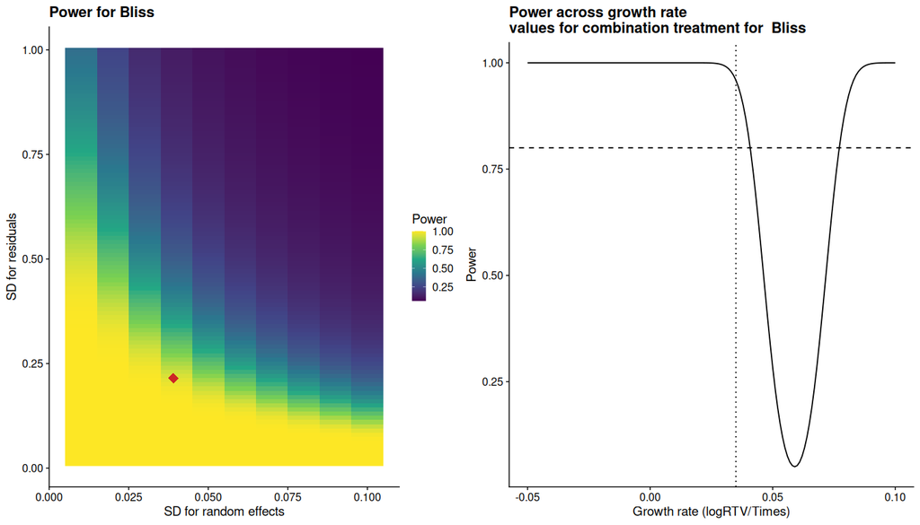

```
#>   numDF denDF  F-value       nc     Power
#> 1     1   317 13.77187 13.77187 0.9590544
```

```r
> APrioriPwr(npg = npg, # Sample size per group, calculated above
            time = days, # Time points of measurements, calculated above
            # Model estimates:
            grwrControl = estimates$Control,
            grwrA = estimates$DrugA,
            grwrB = estimates$DrugB,
            grwrComb = estimates$Combination,
            sd_ranef = estimates$sd_ranef,
            sgma = estimates$sd_resid,
            sd_eval = seq(0.01, 0.1, 0.01),
            sgma_eval = seq(0.01, 1, 0.01),
            grwrComb_eval = seq(-0.05, 0.1, 0.001)
            )
```

The red dot and the vertical line in the plots indicate the power result corresponding to the values assigned to `sd_ranef`, `sgma`, and `grwrComb`, respectively.

The results demonstrate that the power increases as the residual and random effects variances decrease. Furthermore, the plot on the right reveals a U-shaped power profile as a function of the combination group growth rate. This indicates that with lower growth rates (i.e., higher effect size), the power is increased for detecting synergy, but it decreases as growth rates approach the expected additive effect under the Bliss independence model until it reaches its minimum. As growth rates exceed the expected additive effect, the power starts to increase again, reflecting the model’s ability to detect negative deviations from additivity (indicating antagonism).

All these functions constitute an interesting toolbox for the researcher. One may perform a first pilot experiment, and then optimize the study design based on the data from that experiment.

## 5. Citation

To cite `SynergyLMM` in publications use:

Romero-Becerra R, Zhao Z, Nebdal D, Müller E, Bergholtz H, Norum JH, Aittokallio T (2025). “Improved analysis of in vivo drug combination experiments with a comprehensive statistical framework and web-tool.” *Nature Communications*, *16*(1), 10151. doi:10.1038/s41467-025-65218-9 https://doi.org/10.1038/s41467-025-65218-9.